## 주제 : 영화 관객 수 예측 모델 (이혜진)

- 출처 : 데이콘 영화 관객수 예측 경진대회(https://dacon.io/competitions/open/235536/overview/description)

# 1. EDA

- title : 영화의 제목
- distributor : 배급사
- genre : 장르
- release_time : 개봉일
- time : 상영시간(분)
- screening_rat : 상영등급
- director : 감독이름
- dir_prev_bfnum : 해당 감독이 이 영화를 만들기 전 제작에 참여한 영화에서의 평균 관객수(단, 관객수가 알려지지 않은 영화 제외)
- dir_prev_num : 해당 감독이 이 영화를 만들기 전 제작에 참여한 영화의 개수(단, 관객수가 알려지지 않은 영화 제외)
- num_staff : 스텝수
- num_actor : 주연배우수
- box_off_num : 관객수

```python
import pandas as pd
import numpy as np
import seaborn as sns
import matplotlib.pyplot as plt
import re
import warnings
warnings.filterwarnings('ignore')
from sklearn.ensemble import GradientBoostingRegressor, RandomForestRegressor
from sklearn.metrics import mean_squared_error
from sklearn.model_selection import KFold

# 데이터 불러오기
train = pd.read_csv('./movies_train.csv', encoding='cp949')
test = pd.read_csv('./movies_test.csv', encoding='utf-8')
sub = pd.read_csv('./submission.csv', encoding='utf-8')
```

```python
train.head()
```

|  | title | distributor | genre | release_time | time | screening_rat | director | dir_prev_bfnum | dir_prev_num | num_staff | num_actor | box_off_num |
| --- | --- | --- | --- | --- | --- | --- | --- | --- | --- | --- | --- | --- |
| 0 | 개들의 전쟁 | 롯데엔터테인먼트 | 액션 | 2012-11-22 | 96 | 청소년 관람불가 | 조병옥 | NaN | 0 | 91 | 2 | 23398 |
| 1 | 내부자들 | (주)쇼박스 | 느와르 | 2015-11-19 | 130 | 청소년 관람불가 | 우민호 | 1161602.50 | 2 | 387 | 3 | 7072501 |
| 2 | 은밀하게 위대하게 | (주)쇼박스 | 액션 | 2013-06-05 | 123 | 15세 관람가 | 장철수 | 220775.25 | 4 | 343 | 4 | 6959083 |
| 3 | 나는 공무원이다 | (주)NEW | 코미디 | 2012-07-12 | 101 | 전체 관람가 | 구자홍 | 23894.00 | 2 | 20 | 6 | 217866 |
| 4 | 불량남녀 | 쇼박스(주)미디어플렉스 | 코미디 | 2010-11-04 | 108 | 15세 관람가 | 신근호 | 1.00 | 1 | 251 | 2 | 483387 |

```python
print(train.shape)
```

```
(600, 12)
```

```python
# train / test 둘 다 컬럼 'dir_prev_bfnum(해당 감독이 이전에 만든 영화의 관객 수)'에 결측치 있음
train.info()
```

```
<class 'pandas.core.frame.DataFrame'>
RangeIndex: 600 entries, 0 to 599
Data columns (total 12 columns):
 #   Column          Non-Null Count  Dtype
---  ------          --------------  -----
 0   title           600 non-null    object
 1   distributor     600 non-null    object
 2   genre           600 non-null    object
 3   release_time    600 non-null    object
 4   time            600 non-null    int64
 5   screening_rat   600 non-null    object
 6   director        600 non-null    object
 7   dir_prev_bfnum  270 non-null    float64
 8   dir_prev_num    600 non-null    int64
 9   num_staff       600 non-null    int64
 10  num_actor       600 non-null    int64
 11  box_off_num     600 non-null    int64
dtypes: float64(1), int64(5), object(6)
memory usage: 56.4+ KB
```

```python
# 수치변수들 통계량 확인
train.describe().T
```

|  | count | mean | std | min | 25% | 50% | 75% | max |
| --- | --- | --- | --- | --- | --- | --- | --- | --- |
| time | 600.0 | 1.008633e+02 | 1.809753e+01 | 45.0 | 89.00 | 100.000 | 114.000 | 180.0 |
| dir_prev_bfnum | 270.0 | 1.050443e+06 | 1.791408e+06 | 1.0 | 20380.00 | 478423.625 | 1286568.625 | 17615314.0 |
| dir_prev_num | 600.0 | 8.766667e-01 | 1.183409e+00 | 0.0 | 0.00 | 0.000 | 2.000 | 5.0 |
| num_staff | 600.0 | 1.511183e+02 | 1.656547e+02 | 0.0 | 17.00 | 82.500 | 264.000 | 869.0 |
| num_actor | 600.0 | 3.706667e+00 | 2.446889e+00 | 0.0 | 2.00 | 3.000 | 4.000 | 25.0 |
| box_off_num | 600.0 | 7.081818e+05 | 1.828006e+06 | 1.0 | 1297.25 | 12591.000 | 479886.750 | 14262766.0 |

```python
# 정수
pd.options.display.float_format = '{:.1f}'.format
```

```python
# 장르별 관객수
train[['genre', 'box_off_num']].groupby('genre').mean().sort_values('box_off_num')
```

| genre | box_off_num |
| --- | --- |
| 뮤지컬 | 6627.0 |
| 다큐멘터리 | 67172.3 |
| 서스펜스 | 82611.0 |
| 애니메이션 | 181926.7 |
| 멜로/로맨스 | 425968.0 |
| 미스터리 | 527548.2 |
| 공포 | 590832.5 |
| 드라마 | 625689.8 |
| 코미디 | 1193914.0 |
| SF | 1788345.7 |
| 액션 | 2203974.1 |
| 느와르 | 2263695.1 |

```python
# # 장르, 상영등급 (수치화)
# from sklearn import preprocessing

# le = preprocessing.LabelEncoder()

# train['genre'] = le.fit_transform(train['genre'])
# train['screening_rat'] = le.fit_transform(train['screening_rat'])
```

```python
# # dir_prev_bfnum, num_staff (log 정규화)
# train["dir_prev_bfnum"] = np.log1p(train["dir_prev_bfnum"])
# train["num_staff"] = np.log1p(train["num_staff"])
```

### 변수 간 상관계수 확인

```python
train.corr()
```

|  | time | dir_prev_bfnum | dir_prev_num | num_staff | num_actor | box_off_num |
| --- | --- | --- | --- | --- | --- | --- |
| time | 1.0 | 0.3 | 0.3 | 0.6 | 0.1 | 0.4 |
| dir_prev_bfnum | 0.3 | 1.0 | 0.1 | 0.3 | 0.1 | 0.3 |
| dir_prev_num | 0.3 | 0.1 | 1.0 | 0.5 | 0.0 | 0.3 |
| num_staff | 0.6 | 0.3 | 0.5 | 1.0 | 0.1 | 0.5 |
| num_actor | 0.1 | 0.1 | 0.0 | 0.1 | 1.0 | 0.1 |
| box_off_num | 0.4 | 0.3 | 0.3 | 0.5 | 0.1 | 1.0 |

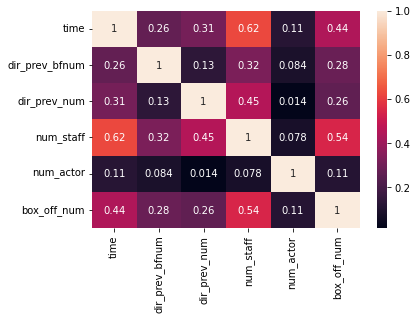

```python
# 히트맵
import seaborn as sns
sns.heatmap(train.corr(), annot=True)
```

- box_off_num과 상관관계있는 변수 : num_staff, time

### 히스토그램으로 변수 분포 확인: 오른쪽으로 꼬리가 긴 분포를 가진 변수에는 log 변환 필요

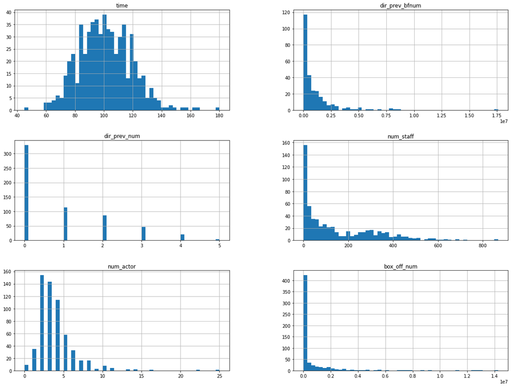

```python
# 히스토그램

import matplotlib.pyplot as plt
%matplotlib inline

train.hist(bins = 50, figsize = (20,15))
plt.show()
```

## 2. 전처리

```python
# 배급사 전처리
train['distributor'] = train.distributor.str.replace("(주)", '')
train['distributor'] = [re.sub(r'[^0-9a-zA-Z가-힣]', '', x) for x in train.distributor]
```

```python
def get_dis(x) :
    if 'CJ' in x or 'CGV' in x :
        return 'CJ'
    elif '쇼박스' in x :
        return '쇼박스'
    elif 'SK' in x :
        return 'SK'
    elif '리틀빅픽' in x :
        return '리틀빅픽처스'
    elif '스폰지' in x :
        return '스폰지'
    elif '싸이더스' in x :
        return '싸이더스'
    elif '에이원' in x :
        return '에이원'
    elif '마인스' in x :
        return '마인스'
    elif '마운틴픽' in x :
        return '마운틴픽처스'
    elif '디씨드' in x :
        return '디씨드'
    elif '드림팩트' in x :
        return '드림팩트'
    elif '메가박스' in x :
        return '메가박스'
    elif '마운틴' in x :
        return '마운틴'
    else :
        return x
```

```python
train['distributor'] = train.distributor.apply(get_dis)
```

```python
train
```

|  | title | distributor | genre | release_time | time | screening_rat | director | dir_prev_bfnum | dir_prev_num | num_staff | num_actor | box_off_num |
| --- | --- | --- | --- | --- | --- | --- | --- | --- | --- | --- | --- | --- |
| 0 | 개들의 전쟁 | 롯데엔터테인먼트 | 액션 | 2012-11-22 | 96 | 청소년 관람불가 | 조병옥 | NaN | 0 | 91 | 2 | 23398 |
| 1 | 내부자들 | 쇼박스 | 느와르 | 2015-11-19 | 130 | 청소년 관람불가 | 우민호 | 1161602.5 | 2 | 387 | 3 | 7072501 |
| 2 | 은밀하게 위대하게 | 쇼박스 | 액션 | 2013-06-05 | 123 | 15세 관람가 | 장철수 | 220775.2 | 4 | 343 | 4 | 6959083 |
| 3 | 나는 공무원이다 | NEW | 코미디 | 2012-07-12 | 101 | 전체 관람가 | 구자홍 | 23894.0 | 2 | 20 | 6 | 217866 |
| 4 | 불량남녀 | 쇼박스 | 코미디 | 2010-11-04 | 108 | 15세 관람가 | 신근호 | 1.0 | 1 | 251 | 2 | 483387 |
| ... | ... | ... | ... | ... | ... | ... | ... | ... | ... | ... | ... | ... |
| 595 | 해무 | NEW | 드라마 | 2014-08-13 | 111 | 청소년 관람불가 | 심성보 | 3833.0 | 1 | 510 | 7 | 1475091 |
| 596 | 파파로티 | 쇼박스 | 드라마 | 2013-03-14 | 127 | 15세 관람가 | 윤종찬 | 496061.0 | 1 | 286 | 6 | 1716438 |
| 597 | 살인의 강 | 마운틴픽처스 | 공포 | 2010-09-30 | 99 | 청소년 관람불가 | 김대현 | NaN | 0 | 123 | 4 | 2475 |
| 598 | 악의 연대기 | CJ | 느와르 | 2015-05-14 | 102 | 15세 관람가 | 백운학 | NaN | 0 | 431 | 4 | 2192525 |
| 599 | 베를린 | CJ | 액션 | 2013-01-30 | 120 | 15세 관람가 | 류승완 | NaN | 0 | 363 | 5 | 7166532 |

600 rows × 12 columns

### 2-2. 장르 별 관객 수 평균값으로 rank 인코딩(genre_rank)

```python
# 장르별 영화 관객수 평균값으로 랭크 인코딩 : 느와르, 액션이 인기 장르
train.groupby('genre').box_off_num.mean().sort_values()
```

```
genre
뮤지컬         6627.0
다큐멘터리      67172.3
서스펜스       82611.0
애니메이션     181926.7
멜로/로맨스    425968.0
미스터리      527548.2
공포        590832.5
드라마       625689.8
코미디      1193914.0
SF       1788345.7
액션       2203974.1
느와르      2263695.1
Name: box_off_num, dtype: float64
```

```python
# 'genre_rank' 컬럼 생성 (genre 수치화)
train['genre_rank'] = train.genre.map({'뮤지컬' : 1, '다큐멘터리' : 2, '서스펜스' : 3, '애니메이션' : 4,
                                       '멜로/로맨스' : 5, '미스터리' : 6, '공포' : 7, '드라마' : 8,
                                       '코미디' : 9, 'SF' : 10, '액션' : 11, '느와르' : 12})
```

```python
# 배급사 기준 관객수 중앙값
train.groupby('distributor').box_off_num.median()
```

```
distributor
BoXoo엔터테인먼트      2078.5
CJ            1084269.0
JK필름           688639.0
KBS미디어           7956.0
KT             167024.0
                 ...
하준사               600.0
한국YWCA연합회          71.0
홀리가든             1778.5
화앤담이엔티         172196.5
휘엔터테인먼트           228.0
Name: box_off_num, Length: 147, dtype: float64
```

```python
tr_num_rank = train.groupby('distributor').box_off_num.median().reset_index(name = 'num_rank').sort_values(by = 'num_rank')
tr_num_rank
```

|  | distributor | num_rank |
| --- | --- | --- |
| 110 | 인피니티엔터테인먼트 | 2.0 |
| 15 | 고구마공작소 | 8.0 |
| 52 | 사람과사람들 | 42.0 |
| 97 | 위드시네마 | 46.0 |
| 19 | 나우콘텐츠 | 54.0 |
| ... | ... | ... |
| 113 | 전망좋은영화사 | 1214237.0 |
| 105 | 이십세기폭스코리아 | 1422844.0 |
| 56 | 쇼박스 | 2138560.0 |
| 84 | 영구아트무비 | 2541603.0 |
| 75 | 아이필름코퍼레이션 | 3117859.0 |

147 rows × 2 columns

```python
# 최종 데이터 병합
train = pd.merge(train, tr_num_rank, how = 'left')
train
```

|  | title | distributor | genre | release_time | time | screening_rat | director | dir_prev_bfnum | dir_prev_num | num_staff | num_actor | box_off_num | genre_rank | num_rank |
| --- | --- | --- | --- | --- | --- | --- | --- | --- | --- | --- | --- | --- | --- | --- |
| 0 | 개들의 전쟁 | 롯데엔터테인먼트 | 액션 | 2012-11-22 | 96 | 청소년 관람불가 | 조병옥 | NaN | 0 | 91 | 2 | 23398 | 11 | 612772.0 |
| 1 | 내부자들 | 쇼박스 | 느와르 | 2015-11-19 | 130 | 청소년 관람불가 | 우민호 | 1161602.5 | 2 | 387 | 3 | 7072501 | 12 | 2138560.0 |
| 2 | 은밀하게 위대하게 | 쇼박스 | 액션 | 2013-06-05 | 123 | 15세 관람가 | 장철수 | 220775.2 | 4 | 343 | 4 | 6959083 | 11 | 2138560.0 |
| 3 | 나는 공무원이다 | NEW | 코미디 | 2012-07-12 | 101 | 전체 관람가 | 구자홍 | 23894.0 | 2 | 20 | 6 | 217866 | 9 | 954892.5 |
| 4 | 불량남녀 | 쇼박스 | 코미디 | 2010-11-04 | 108 | 15세 관람가 | 신근호 | 1.0 | 1 | 251 | 2 | 483387 | 9 | 2138560.0 |
| ... | ... | ... | ... | ... | ... | ... | ... | ... | ... | ... | ... | ... | ... | ... |
| 595 | 해무 | NEW | 드라마 | 2014-08-13 | 111 | 청소년 관람불가 | 심성보 | 3833.0 | 1 | 510 | 7 | 1475091 | 8 | 954892.5 |
| 596 | 파파로티 | 쇼박스 | 드라마 | 2013-03-14 | 127 | 15세 관람가 | 윤종찬 | 496061.0 | 1 | 286 | 6 | 1716438 | 8 | 2138560.0 |
| 597 | 살인의 강 | 마운틴픽처스 | 공포 | 2010-09-30 | 99 | 청소년 관람불가 | 김대현 | NaN | 0 | 123 | 4 | 2475 | 7 | 1198.0 |
| 598 | 악의 연대기 | CJ | 느와르 | 2015-05-14 | 102 | 15세 관람가 | 백운학 | NaN | 0 | 431 | 4 | 2192525 | 12 | 1084269.0 |
| 599 | 베를린 | CJ | 액션 | 2013-01-30 | 120 | 15세 관람가 | 류승완 | NaN | 0 | 363 | 5 | 7166532 | 11 | 1084269.0 |

600 rows × 14 columns

```python
train[train['dir_prev_bfnum'].isnull()]
```

|  | title | distributor | genre | release_time | time | screening_rat | director | dir_prev_bfnum | dir_prev_num | num_staff | num_actor | box_off_num | genre_rank | num_rank |
| --- | --- | --- | --- | --- | --- | --- | --- | --- | --- | --- | --- | --- | --- | --- |
| 0 | 개들의 전쟁 | 롯데엔터테인먼트 | 액션 | 2012-11-22 | 96 | 청소년 관람불가 | 조병옥 | NaN | 0 | 91 | 2 | 23398 | 11 | 612772.0 |
| 6 | 길위에서 | 백두대간 | 다큐멘터리 | 2013-05-23 | 104 | 전체 관람가 | 이창재 | NaN | 0 | 32 | 5 | 53526 | 2 | 27283.0 |
| 8 | 1789, 바스티유의 연인들 | 유니버설픽쳐스인터내셔널코리아 | 뮤지컬 | 2014-09-18 | 129 | 전체 관람가 | 정성복 | NaN | 0 | 3 | 5 | 4778 | 1 | 4778.0 |
| 9 | 청춘그루브 | 두타연 | 드라마 | 2012-03-15 | 94 | 15세 관람가 | 변성현 | NaN | 0 | 138 | 3 | 868 | 8 | 868.0 |
| 10 | AV 아이돌 | 케이알씨지 | 멜로/로맨스 | 2015-07-27 | 89 | 청소년 관람불가 | 조조 히데오 | NaN | 0 | 0 | 4 | 745 | 5 | 629.5 |
| ... | ... | ... | ... | ... | ... | ... | ... | ... | ... | ... | ... | ... | ... | ... |
| 593 | 낭만파 남편의 편지 | 퍼스트런 | 미스터리 | 2013-09-12 | 97 | 청소년 관람불가 | 최위안 | NaN | 0 | 5 | 3 | 1132 | 6 | 1132.0 |
| 594 | 오빠가 돌아왔다 | 마운틴픽처스 | 코미디 | 2014-03-20 | 94 | 청소년 관람불가 | 노진수 | NaN | 0 | 37 | 5 | 1958 | 9 | 1198.0 |
| 597 | 살인의 강 | 마운틴픽처스 | 공포 | 2010-09-30 | 99 | 청소년 관람불가 | 김대현 | NaN | 0 | 123 | 4 | 2475 | 7 | 1198.0 |
| 598 | 악의 연대기 | CJ | 느와르 | 2015-05-14 | 102 | 15세 관람가 | 백운학 | NaN | 0 | 431 | 4 | 2192525 | 12 | 1084269.0 |
| 599 | 베를린 | CJ | 액션 | 2013-01-30 | 120 | 15세 관람가 | 류승완 | NaN | 0 | 363 | 5 | 7166532 | 11 | 1084269.0 |

330 rows × 14 columns

```python
# 결측치가 있는 행의 dir_prev_num 이 모두 0임 --> 모든 데이터가 0인지 확인하기
train[train['dir_prev_bfnum'].isnull()]['dir_prev_num'].sum()
```

```
0
```

```python
#모두 0이므로 해당 감독이 이전에 만든 영화가 없는 경우에만 결측치가 생김 -> 0으로 대체
train['dir_prev_bfnum'].fillna(0, inplace=True)
```

```python
train
```

|  | title | distributor | genre | release_time | time | screening_rat | director | dir_prev_bfnum | dir_prev_num | num_staff | num_actor | box_off_num | genre_rank | num_rank |
| --- | --- | --- | --- | --- | --- | --- | --- | --- | --- | --- | --- | --- | --- | --- |
| 0 | 개들의 전쟁 | 롯데엔터테인먼트 | 액션 | 2012-11-22 | 96 | 청소년 관람불가 | 조병옥 | 0.0 | 0 | 91 | 2 | 23398 | 11 | 612772.0 |
| 1 | 내부자들 | 쇼박스 | 느와르 | 2015-11-19 | 130 | 청소년 관람불가 | 우민호 | 1161602.5 | 2 | 387 | 3 | 7072501 | 12 | 2138560.0 |
| 2 | 은밀하게 위대하게 | 쇼박스 | 액션 | 2013-06-05 | 123 | 15세 관람가 | 장철수 | 220775.2 | 4 | 343 | 4 | 6959083 | 11 | 2138560.0 |
| 3 | 나는 공무원이다 | NEW | 코미디 | 2012-07-12 | 101 | 전체 관람가 | 구자홍 | 23894.0 | 2 | 20 | 6 | 217866 | 9 | 954892.5 |
| 4 | 불량남녀 | 쇼박스 | 코미디 | 2010-11-04 | 108 | 15세 관람가 | 신근호 | 1.0 | 1 | 251 | 2 | 483387 | 9 | 2138560.0 |
| ... | ... | ... | ... | ... | ... | ... | ... | ... | ... | ... | ... | ... | ... | ... |
| 595 | 해무 | NEW | 드라마 | 2014-08-13 | 111 | 청소년 관람불가 | 심성보 | 3833.0 | 1 | 510 | 7 | 1475091 | 8 | 954892.5 |
| 596 | 파파로티 | 쇼박스 | 드라마 | 2013-03-14 | 127 | 15세 관람가 | 윤종찬 | 496061.0 | 1 | 286 | 6 | 1716438 | 8 | 2138560.0 |
| 597 | 살인의 강 | 마운틴픽처스 | 공포 | 2010-09-30 | 99 | 청소년 관람불가 | 김대현 | 0.0 | 0 | 123 | 4 | 2475 | 7 | 1198.0 |
| 598 | 악의 연대기 | CJ | 느와르 | 2015-05-14 | 102 | 15세 관람가 | 백운학 | 0.0 | 0 | 431 | 4 | 2192525 | 12 | 1084269.0 |
| 599 | 베를린 | CJ | 액션 | 2013-01-30 | 120 | 15세 관람가 | 류승완 | 0.0 | 0 | 363 | 5 | 7166532 | 11 | 1084269.0 |

600 rows × 14 columns

### 타겟 값인 관객 수, 출연 배우 수를 로그변환

```python
# 타겟 값인 관객수를 로그변환
X = train[['num_rank', 'time', 'num_staff', 'num_actor', 'genre_rank', 'screening_rat']]
y = np.log1p(train.box_off_num)
```

```python
# 출연 배우 수는 로그변환
X['num_actor'] = np.log1p(X['num_actor'])
```

### 상영등급 pd.get_dummies 로 더미변수로 만들기(screening_rat)

```python
# 상영등급은 더미 변수
X = pd.get_dummies(columns = ['screening_rat'], data = X)
```

- data

```python
Data = train[['num_rank', 'time', 'num_staff', 'num_actor', 'genre_rank']]
```

```python
#Data = pd.get_dummies(columns = ['screening_rat'], data = Data)
```

```python
Data['num_actor'] = np.log1p(Data['num_actor'])
```

```python
Data['num_rank'] = np.log1p(Data['num_rank'])
```

```python
Data['num_staff'] = np.log1p(Data['num_staff'])
```

```python
Data
```

|  | num_rank | time | num_staff | num_actor | genre_rank |
| --- | --- | --- | --- | --- | --- |
| 0 | 13.3 | 96 | 4.5 | 1.1 | 11 |
| 1 | 14.6 | 130 | 6.0 | 1.4 | 12 |
| 2 | 14.6 | 123 | 5.8 | 1.6 | 11 |
| 3 | 13.8 | 101 | 3.0 | 1.9 | 9 |
| 4 | 14.6 | 108 | 5.5 | 1.1 | 9 |
| ... | ... | ... | ... | ... | ... |
| 595 | 13.8 | 111 | 6.2 | 2.1 | 8 |
| 596 | 14.6 | 127 | 5.7 | 1.9 | 8 |
| 597 | 7.1 | 99 | 4.8 | 1.6 | 7 |
| 598 | 13.9 | 102 | 6.1 | 1.6 | 12 |
| 599 | 13.9 | 120 | 5.9 | 1.8 | 11 |

600 rows × 5 columns

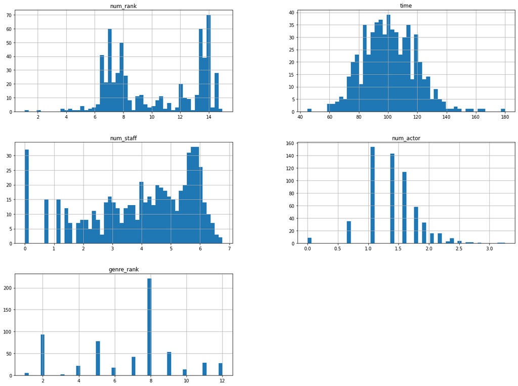

```python
# target 히스토그램
import matplotlib.pyplot as plt
%matplotlib inline

Data.hist(bins = 50, figsize = (20,15))
plt.show()
```

```python
from sklearn.model_selection import GridSearchCV

ftr_importances_values = model.feature_importances_
ftr_importances = pd.Series(ftr_importances_values, index = Data.columns)
ftr_top20 = ftr_importances.sort_values(ascending=False)[:20]

plt.figure(figsize=(8,6))
plt.title('Ranking Feature Importances')
sns.barplot(x=ftr_top20, y=ftr_top20.index)
plt.show()
```

[output not shown]

```python
# train / test 나누기
from sklearn.model_selection import train_test_split

train_input, test_input, train_target, test_target = train_test_split(Data,
                                                                      train['box_off_num'],
                                                                      stratify=Data['genre_rank'],
                                                                      random_state=42)

print(train_input.shape)
```

```
(450, 5)
```

## scale

```python
from sklearn.preprocessing import MinMaxScaler

# 훈련데이터에 대해 스케일링 적용을 위한 조사
scaler = MinMaxScaler()
scaler.fit(train_input)

# 훈련데이터에 대해 스케일링 적용
X_train_scaled = scaler.transform(train_input)

# 테스트데이터에 대해 스케일링 적용
X_test_scaled = scaler.transform(test_input)
```

## all_estimators

```python
from sklearn.utils import all_estimators
import numpy as np
```

```python
# 필터 타입에 해당하는 sklearn에 존재하는 모든 모델 이름과 객체 리스트로 반환
models = all_estimators(type_filter='regressor')
```

```python
scores = []
names = []

for name, model in models:
    try:
        # 모델 객체 생성
        md = model()
        # 학습
        md.fit(X_train_scaled, train_target)
        # 평가
        result = md.score(X_train_scaled, train_target) # train
        names.append(name)
        scores.append((name, np.round(result,3)))
    except:
        pass
```

```python
scores
```

```
[('ARDRegression', 0.0),
 ('AdaBoostRegressor', 0.633),
 ('BaggingRegressor', 0.873),
 ('BayesianRidge', 0.0),
 ('CCA', -0.276),
 ('DecisionTreeRegressor', 1.0),
 ('DummyRegressor', 0.0),
 ('ElasticNet', 0.084),
 ('ElasticNetCV', 0.0),
 ('ExtraTreeRegressor', 1.0),
 ('ExtraTreesRegressor', 1.0),
 ('GammaRegressor', 0.052),
 ('GaussianProcessRegressor', 0.868),
 ('GradientBoostingRegressor', 0.893),
 ('HistGradientBoostingRegressor', 0.69),
 ('HuberRegressor', -0.02),
 ('KNeighborsRegressor', 0.5),
 ('KernelRidge', 0.187),
 ('Lars', 0.267),
 ('LarsCV', 0.266),
 ('Lasso', 0.267),
 ('LassoCV', 0.266),
 ('LassoLars', 0.267),
 ('LassoLarsCV', 0.266),
 ('LassoLarsIC', 0.266),
 ('LinearRegression', 0.267),
 ('LinearSVR', -0.15),
 ('MLPRegressor', -0.15),
 ('NuSVR', -0.063),
 ('OrthogonalMatchingPursuit', 0.217),
 ('OrthogonalMatchingPursuitCV', 0.267),
 ('PLSCanonical', -0.945),
 ('PLSRegression', 0.263),
 ('PassiveAggressiveRegressor', -0.123),
 ('PoissonRegressor', 0.655),
 ('QuantileRegressor', -0.146),
 ('RANSACRegressor', -0.141),
 ('RadiusNeighborsRegressor', 0.058),
 ('RandomForestRegressor', 0.891),
 ('Ridge', 0.266),
 ('RidgeCV', 0.266),
 ('SGDRegressor', 0.261),
 ('SVR', -0.146),
 ('TheilSenRegressor', 0.067),
 ('TransformedTargetRegressor', 0.267),
 ('TweedieRegressor', 0.049)]
```

## 첫 번째 모델 : ('RandomForestRegressor', 0.891)

```python
# 모델 생성
model_rf = RandomForestRegressor().fit(X_train_scaled, train_target)

# 평가
print("훈련 세트 정확도: {:.3f}".format(model_rf.score(X_train_scaled, train_target)))
print("테스트 세트 정확도: {:.3f}".format(model_rf.score(X_test_scaled, test_target)))
```

```
훈련 세트 정확도: 0.888
테스트 세트 정확도: 0.454
```

## GridSearchCV

```python
param_grid = {
    'bootstrap': [True],
    'max_depth': [100, 110],
    'max_features': [2, 3],
    'min_samples_leaf': [3, 5],
    'min_samples_split': [8, 12],
    'n_estimators': [300, 1000]
}
```

```python
from sklearn.model_selection import GridSearchCV

grid_search = GridSearchCV(model_rf, param_grid, cv=10, return_train_score=True)
grid_search.fit(X_train_scaled, train_target)
print("Best Parameters : ", grid_search.best_params_)
print("Best Score : ", grid_search.best_score_)
print("Best Test Score : ", grid_search.score(X_test_scaled, test_target))
```

```
Best Parameters :  {'bootstrap': True, 'max_depth': 100, 'max_features': 2, 'min_samples_leaf': 5, 'min_samples_split': 12, 'n_estimators': 300}
Best Score :  0.34834854873091003
Best Test Score :  0.4374584842952167
```

```python
param_grid = {
    'bootstrap': [True],
    'max_depth': [100],
    'max_features': [2],
    'min_samples_leaf': [5],
    'min_samples_split': [12],
    'n_estimators': [300]
}
```

```python
# 모델 생성
model_rf_after = RandomForestRegressor(bootstrap = True, max_depth = 100, max_features = 2, min_samples_leaf = 5, min_samples_split = 12, n_estimators = 300).fit(X_train_scaled, train_target)

# 평가
print("훈련 세트 정확도: {:.3f}".format(model_rf.score(X_train_scaled, train_target)))
print("테스트 세트 정확도: {:.3f}".format(model_rf.score(X_test_scaled, test_target)))
```

```
훈련 세트 정확도: 0.888
테스트 세트 정확도: 0.454
```

## k - fold

```python
from sklearn.model_selection import KFold
```

```python
kfold = KFold(n_splits=5)
```

```python
from sklearn.model_selection import cross_validate
# 5-Fold로 5등분으로 나누어서 학습/검증 모델 생성 진행
result = cross_validate(model_rf,
                        Data,
                        train['box_off_num'],
                        return_train_score=True,
                        cv=kfold)
```

```python
result['test_score'].mean()
```

```
0.2346878064466586
```

### RandomForestRegressor 예측

```python
sub = sub[0:150]
```

```python
single = sub.copy()
```

```python
single['box_off_num'] = model_rf.predict(X_test_scaled)
```

```python
single.head()
```

|  | title | box_off_num |
| --- | --- | --- |
| 0 | 용서는 없다 | 183955.3 |
| 1 | 아빠가 여자를 좋아해 | 764936.4 |
| 2 | 하모니 | 65586.4 |
| 3 | 의형제 | 5345.8 |
| 4 | 평행 이론 | 74440.6 |

```python
# 모델 생성
from sklearn.tree import DecisionTreeClassifier

tree = DecisionTreeClassifier(random_state=42)
tree.fit(X_train_scaled, train_target)

# 평가
print("훈련 세트 정확도: {:.3f}".format(tree.score(X_train_scaled, train_target)))
print("테스트 세트 정확도: {:.3f}".format(tree.score(X_test_scaled, test_target)))
```

```
훈련 세트 정확도: 1.000
테스트 세트 정확도: 0.013
```

## GridSearchCV

```python
# parameters={"splitter":["best","random"],
#             "max_depth" : [7,9],
#            "min_samples_leaf":[3,6],
#            "min_weight_fraction_leaf":[0.3,0.8],
#            "max_features":["auto","log2"],
#            "max_leaf_nodes":[30,40,50] }
```

```python
# from sklearn.model_selection import GridSearchCV

# grid_search = GridSearchCV(tree, param_grid=parameters, return_train_score=True)
# grid_search.fit(X_train_scaled, train_target)
# print("Best Parameters : ", grid_search.best_params_)
# print("Best Score : ", grid_search.best_score_)
# print("Best Test Score : ", grid_search.score(X_test_scaled, test_target))
```

## k - fold

```python
from sklearn.model_selection import cross_validate
# 5-Fold로 5등분으로 나누어서 학습/검증 모델 생성 진행
result = cross_validate(tree,
                        Data,
                        train['box_off_num'],
                        return_train_score=True,
                        cv=kfold)
```

```python
result['test_score'].mean()
```

```
0.003333333333333333
```

```python
single.head()
```

[output not shown]

```python
single['box_off_num'] = tree.predict(X_test_scaled)
```

```python
single.head()
```

|  | title | box_off_num |
| --- | --- | --- |
| 0 | 용서는 없다 | 1865354 |
| 1 | 아빠가 여자를 좋아해 | 120806 |
| 2 | 하모니 | 120806 |
| 3 | 의형제 | 714136 |
| 4 | 평행 이론 | 9438 |